# Bellman Equation / Artifical Intelligence

The game can be played [here](https://fdrennan.shinyapps.io/ppig/). It should be very possible to beat the computer, even if it is playing optimally.

Rules for Pig:

- If the player rolls a 1, the player receives 1 point and the turn moves to the opponent.
- If the player rolls 2-6, the amount on the die is added to the turn total.
- The player can repeat the second step as long as desired adding to the turn total. If the player holds, the summed points are added to the players score and it becomes the opponents turn.

### Bellman Equation:

The program will be written from the perspective of one player who is wants to maximize the probability of winning the game. Thus, $i$ will be the number of points this player current has. $j$ will be the number of points the opponent holds and $k$ will be the current “turn total.” Given these states, the bellman equation $V_{i,j,k} = max(P_{roll}\;, P_{hold})$ represents the probability of winning the game. The player at any state of the game must make the decision if the probability of winning the game is greater if he or she holds or rolls again.

$$P_{roll} = \frac{1}{6}\left ((1 - V(j, i, + 1, 0)) +V(i, j, k + 2...6) \right )$$
$$P_{hold} = 1 - V(j, i + max(k, 1), 0)$$

```r
size = 100

pArray <- function(size) {

asc <- function(n) {
  as.character(n)
}

dims <- list()
sN <- size + 5
dims$i <- asc(0:sN)
dims$j <- asc(0:sN)
dims$k <- asc(0:sN)
V <- array(NA, c(size+6, size+6, size+6), dimnames = c(dims))
U <- array(NA, c(size+6, size+6, size+6), dimnames = c(dims))

dims <- list()
dims$i <- asc(0:(sN-1))
dims$j <- asc(0:(sN-1))
# dims$i <- asc(1:(sN))
# dims$j <- asc(1:(sN))
A <- matrix(NA, (sN), (sN), dimnames = dims)

for (x in 1:ncol(A)) {
  for (y in 1:nrow(A)) {
    A[x,y] = (x-1)+(y-1)
  }
}

for (z in (sN*2):0) {
  loc = which(A %in% z)
  for (l in loc) {

    i = trunc(((l+(sN-1)) / (sN)),0)
    j = l - ((i-1)*sN)
    i = i - 1
    j = j - 1

    for(k in sN:0) {

      # cat(z,i,j,k,'\n')
      #
      if((i + k + 1)>=size) {
        V[asc(i), asc(j), asc(k)] = 1
        U[asc(i), asc(j), asc(k)] = 2
      }

      else if (j >= size) {
        V[asc(i), asc(j), asc(k)] <- 0
        U[asc(i), asc(j), asc(k)] <- 2
      }
      else {

        # Calculate the probability of winning with a roll

        prob_roll <- 1 - V[asc(j), asc(i+1), asc(0)]
        for(roll in 2:6) {
          prob_roll <- V[asc(i), asc(j), asc(k+roll)]+prob_roll
        }

        prob_roll <- prob_roll/6

        # Calculate the probability of winning with hold

        prob_hold <- 1 - V[asc(j), asc(i + max(k, 1)), asc(0)]

        # Choose max of probability

        V[asc(i), asc(j), asc(k)] <- max(prob_roll, prob_hold)
        U[asc(i), asc(j), asc(k)] <- which.max(c(prob_roll, prob_hold))
      }
    }
  }
}
for(i in 0:sN) {
     for(j in 0:sN) {
          for(k in 0:sN) {
               # 2 Added the plus 1 because minimum roll added to score
               # is a plus one, already accounted for in loop one
               if((i+k+1) >=size) {
                    V[asc(i),asc(j),asc(k)] <- 1
                    U[asc(i),asc(j),asc(k)] <- 2
               }
               else if(j >= size) {
                    V[asc(i),asc(j),asc(k)] <- 0 #2 added this
                    U[asc(i),asc(j),asc(k)] <- 2
               }
          }
     }
}

# A
returnList <- list()
returnList[["U"]] <- U
returnList[["V"]] <- V
returnList
}

sol <- pArray(100)
V <- sol$V
```

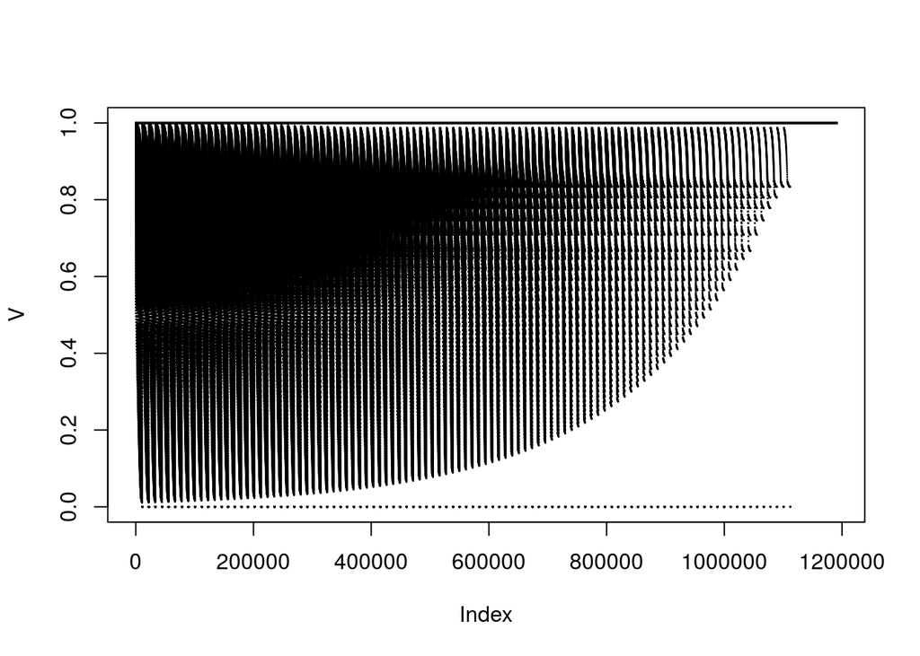

```r
plot(V, cex=.05)
```